# IMDB Web Scraping

Web scraping is a process of generating data from a website which in our case is IMdb(an online database of information related to films, television programs, home videos, video games, and streaming content online – including cast, ratings, and fan and critical reviews).Internet can be a amazing source of data to do various kind of data analysis , web scraping is a skill which helps us to do exactly that. The process used in *this project is completely legal and is my own work, although I have used sites such as stackoverflow to make my code more optimized*

## Objective

There are two objectives of this project, one being showcasing my web scraping skill and the other is to do some exploratory data analysis and try to find some inference on the data scraped.

### Libraries used are as follow:

```python
import bs4
import numpy as np
import pandas as pd
import requests
import matplotlib.pyplot as plt
```

The url from which the data is scrapped : **[IMDb "Top 1000" (Sorted by IMDb Rating Descending)](https://www.imdb.com/search/title/?groups=top_1000&sort=user_rating,desc&count=250&start=0&ref_=adv_nxt)**

Let K be the no of movies we want to analyze out of the top 1000 movies

```python
K = 779
print(f'Taking K as {K}')
```

```
Taking K as 779
```

Bs4 itself can't request webpages from a server, hence we use the request library. Our aim here is to collect data of K no. of movies, so we Define 'Souper' which takes K as its parameter which returns beautifulsoup object 'soup1'. (Since a single webpage can only hold maximum 250 titles we use for loop here)

```python
def Souper(K):
    soup1 = bs4.BeautifulSoup()
    j = np.floor(K/250) + 1
    if K<=250:
        url = requests.get(f'https://www.imdb.com/search/title/?groups=top_1000&sort=user_rating,desc&count={K}&start=0&ref_=adv_nxt').text
        soup1.append(bs4.BeautifulSoup(url,'lxml'))

    if K>250:
        for i in range(int(j)):
            if(((j-i)*250)>=250):
                url = requests.get(f'https://www.imdb.com/search/title/?groups=top_1000&sort=user_rating,desc&count=250&start={(i)*250}&ref_=adv_nxt').text
            if(((j-i)*250)<=250):
                url = requests.get(f'https://www.imdb.com/search/title/?groups=top_1000&sort=user_rating,desc&count={K%250}&start={i*250}&ref_=adv_nxt').text
            soup1.append(bs4.BeautifulSoup(url,'lxml'))
    return soup1
```

```python
type(Souper(K))
```

```
bs4.BeautifulSoup
```

Now, we create set of all tags which contain the various information about the movies.

```python
details = Souper(K).find_all('div',class_="lister-item mode-advanced")
```

```python
type(details)
```

```
bs4.element.ResultSet
```

Attributes i will scrape are :

- Title
- Year
- Certificate
- Runtime
- Genre
- Director
- User Rating
- Stars(main cast)
- US boxoffice
- votes

**The following is the function i used to scrape and simultaneously stored the attributes in a Pandas DataFrame :**

```python
def Tag2df(details):
    title=[]
    year = []
    cert = []
    runtime =[]
    genre =[]
    Director = []
    rating = []
    stars = []
    gross=[]
    votes = []

    for details in details:
        title.append(details.h3.a.text)
        try:
            year.append(int(details.h3.find('span',"lister-item-year text-muted unbold").text.split('(')[1].split(')')[0]))
        except Exception as e:
            year.append(int(details.h3.find('span',"lister-item-year text-muted unbold").text.split('(')[2].split(')')[0]))
        try:
            cert.append(details.p.find('span',class_='certificate').text)
        except Exception as e:
            cert.append(np.nan)
        runtime.append(int(details.p.find('span',class_='runtime').text.split(' ')[0]))
        genre.append(details.p.find('span',class_='genre').text.split('\n')[1])
        try :
            gross.append(float(details.find('p', class_='sort-num_votes-visible').find_all('span', {'name' : 'nv'})[1].text.split('$')[1].split('M')[0]))
        except Exception as e:
            gross.append(np.nan)
        Director.append(details.find('p', class_='').a.text)
        votes.append(int(details.find('p', class_='sort-num_votes-visible').find('span', {'name' : 'nv'})["data-value"]))
        rating.append(float(details.find('div','ratings-bar').strong.text))
        try :
            st = ''
            for s in details.find('p', class_='').find_all('a'):
                st += s.text + ' / '
                stx = st.split('/')
                sti = stx[1:(len(st)-1)]
            stars.append(sti)
        except Exception as e:
            stars.append(np.nan)
    da = pd.DataFrame({"title" : title
                        ,"year" : year
                        ,"cert" : cert
                        ,"runtime in minutes" : runtime
                        ,"genre" : genre
                        ,"Director":Director
                        ,"rating":rating
                        ,"stars":stars
                        ,"gross(in million dollars)":gross
                        ,"votes":votes})
    return da
```

```python
len(Tag2df(details).title)
```

```
779
```

```python
da = Tag2df(details)
```

**Our DataFrame** ::

```python
da.head()
```

|  | title | year | cert | runtime in minutes | genre | Director | rating | stars | gross(in million dollars) | votes |
| --- | --- | --- | --- | --- | --- | --- | --- | --- | --- | --- |
| 0 | Jai Bhim | 2021 | A | 164 | Crime, Drama | T.J. Gnanavel | 9.4 | [ Suriya , Lijo Mol Jose , Manikandan , Raj... | NaN | 159001 |
| 1 | The Shawshank Redemption | 1994 | A | 142 | Drama | Frank Darabont | 9.3 | [ Tim Robbins , Morgan Freeman , Bob Gunton ... | 28.34 | 2507279 |
| 2 | The Godfather | 1972 | A | 175 | Crime, Drama | Francis Ford Coppola | 9.2 | [ Marlon Brando , Al Pacino , James Caan , ... | 134.97 | 1727870 |
| 3 | Spider-Man: No Way Home | 2021 | UA | 148 | Action, Adventure, Fantasy | Jon Watts | 9.1 | [ Tom Holland , Zendaya , Benedict Cumberbat... | NaN | 156548 |
| 4 | Soorarai Pottru | 2020 | U | 153 | Drama | Sudha Kongara | 9.1 | [ Suriya , Paresh Rawal , Aparna Balamurali ... | NaN | 104744 |

# EDA using Pandas

Now let’s Explore the data we just scraped.**I have used the word popular not great for the higher rated movies because this survey is based on convenience sampling**

**DISCLAIMER: The data are of the top 1000 movies according to IMDb users, I don't support any of the inferences. This project is done only to showcase my skills.**

```python
print(f'The ratings of all the movies lie between : {da.rating.min()} and {da.rating.max()}')
```

```
The ratings of all the movies lie between : 7.7 and 9.4
```

###### Now lets see the distribution of the movies on the basis of their genre:

```python
da['genre'].value_counts()
```

```
Drama                                   70
Drama, Romance                          31
Comedy, Drama                           27
Crime, Drama                            25
Action, Crime, Drama                    23
                                        ..
Crime, Drama, Musical                    1
Family, Fantasy, Musical                 1
Comedy, Drama, Sci-Fi                    1
Comedy, Music, Romance                   1
Drama, Horror, Thriller                  1
Name: genre, Length: 196, dtype: int64
```

*The average runtime and rating of all the genres :*

```python
av_runtime =pd.DataFrame(da.groupby('genre')['runtime in minutes'].mean()).rename(columns =
                                                                      {"runtime in minutes" : "Average Runtime"}).sort_values(
                                                                                by ='Average Runtime' , ascending = False)
av_rating = pd.DataFrame(da.groupby('genre')['rating'].mean()).rename(columns = {"rating" : "Average Rating"}).sort_values(
                                                                                by ='Average Rating' , ascending = False)

Genre_details = pd.concat([av_runtime,av_rating],axis=1)

Genre_details
```

| genre | Average Runtime | Average Rating |
| --- | --- | --- |
| Drama, Musical, Sport | 224.000000 | 8.100000 |
| Adventure, Drama, Family | 220.000000 | 7.900000 |
| Adventure, Drama, History | 189.666667 | 8.133333 |
| Comedy, Drama, Musical | 186.000000 | 7.900000 |
| Drama, History, Romance | 181.500000 | 8.100000 |
| ... | ... | ... |
| Animation, Crime, Mystery | 81.000000 | 8.000000 |
| Drama, Horror, Sci-Fi | 72.500000 | 7.800000 |
| Comedy, Family, Romance | 72.000000 | 8.100000 |
| Animation, Sci-Fi | 72.000000 | 7.800000 |
| Comedy, Musical | 69.000000 | 7.800000 |

196 rows × 2 columns

The above table infere that Dramatical movies tend to be longer since the all relatively long movies have drama in thier genre.

The most Popular Genre :

```python
Genre_details[Genre_details['Average Rating']==Genre_details['Average Rating'].max()]
```

| genre | Average Runtime | Average Rating |
| --- | --- | --- |
| Adventure, Western | 161.0 | 8.8 |

Now,lets move to the directors. We will try to find out that according to IMDb users who is the most popular and according to their boxoffice numbers who is the most successfull(we will se the top 10 list):

**Defining Find_Top_Dir(By = "Field", N = number of the directors, minMovies = minimum no. of movies)**

```python
def Find_Top_Dir(By,N,minMovies):
    a = da.groupby('Director')[By].mean()

    k = da.Director.value_counts().sort_index(ascending = True)

    da2 = pd.concat([a,k], axis=1)

    da2.rename(columns={'Director':'No. of films',By:'Mean Rating'},inplace=True)

    da2['Director'] = da2.index

    da2 = da2[['Director','Mean Rating','No. of films']]    #sorting the attributes

    da2.reset_index(inplace=True)                           #Changing the Index

    da2.drop(columns="index",inplace=True)                  #droping the old Index

    filt = da2['No. of films'] > minMovies

    da2 = da2[filt].sort_values(by = ['Mean Rating', 'No. of films'] , ascending = [False,False]).head(N).reset_index()

    da2.drop(columns="index",inplace=True)                  #droping the old Index

    return da2
```

**Now lets see who has the highest average ratings for thier movies :**

```python
Find_Top_Dir('rating',10,4)
```

|  | Director | Mean Rating | No. of films |
| --- | --- | --- | --- |
| 0 | Christopher Nolan | 8.462500 | 8 |
| 1 | Peter Jackson | 8.400000 | 5 |
| 2 | Sergio Leone | 8.360000 | 5 |
| 3 | Charles Chaplin | 8.333333 | 6 |
| 4 | Quentin Tarantino | 8.257143 | 7 |
| 5 | Stanley Kubrick | 8.233333 | 9 |
| 6 | David Fincher | 8.220000 | 5 |
| 7 | Steven Spielberg | 8.211111 | 9 |
| 8 | Billy Wilder | 8.200000 | 8 |
| 9 | Martin Scorsese | 8.200000 | 9 |

The above list has a condition to it i.e. the directors must have done atleast 5 movies

**Now lets see who has the highest average Boxoffice for thier movies by changing the field:**

```python
Find_Top_Dir('gross(in million dollars)',10,2)
```

|  | Director | Mean Rating | No. of films |
| --- | --- | --- | --- |
| 0 | Anthony Russo | 551.260000 | 4 |
| 1 | James Cameron | 349.648000 | 5 |
| 2 | Peter Jackson | 319.462000 | 5 |
| 3 | Pete Docter | 313.126667 | 4 |
| 4 | Christopher Nolan | 242.181250 | 8 |
| 5 | Steven Spielberg | 235.491111 | 9 |
| 6 | Robert Zemeckis | 223.247500 | 4 |
| 7 | Sam Mendes | 197.896667 | 3 |
| 8 | Alfonso Cuarón | 186.333333 | 4 |
| 9 | Brad Bird | 163.683333 | 3 |

Anthony Russo leads the list(thanks to the huge marvel fan base)

**Before moving on, lets just see who's the most experienced Director (if no. of films are same ,then sort by av rating) :**

```python
fg = Find_Top_Dir('rating',10,4).sort_values(by = [ 'No. of films','Mean Rating'] , ascending = [False,False]).head(10)
fg.reset_index(inplace=True)
fg.drop(columns="index")
```

|  | Director | Mean Rating | No. of films |
| --- | --- | --- | --- |
| 0 | Stanley Kubrick | 8.233333 | 9 |
| 1 | Steven Spielberg | 8.211111 | 9 |
| 2 | Martin Scorsese | 8.200000 | 9 |
| 3 | Christopher Nolan | 8.462500 | 8 |
| 4 | Billy Wilder | 8.200000 | 8 |
| 5 | Quentin Tarantino | 8.257143 | 7 |
| 6 | Charles Chaplin | 8.333333 | 6 |
| 7 | Peter Jackson | 8.400000 | 5 |
| 8 | Sergio Leone | 8.360000 | 5 |
| 9 | David Fincher | 8.220000 | 5 |

*Lets what is the time span of our data:*

```python
(da.year.min(),da.year.max())
```

```
(1920, 2021)
```

Here, we introduce a new attribute *'Decade'* which we compute using pandas:

```python
da['Decade'] = pd.cut(da.year.astype(int) , [1920
,1930
,1940
,1950
,1960
,1970
,1980
,1990
,2000
,2010
,2020,2022 ])
```

*lets, see the Certification distrubution*(i.e. how many movies are of which certificate)

```python
pd.DataFrame(da.cert.value_counts()).rename(columns = {'cert' : 'Count'})
```

|  | Count |
| --- | --- |
| U | 214 |
| A | 156 |
| UA | 152 |
| R | 54 |
| PG-13 | 15 |
| PG | 10 |
| 18 | 10 |
| 16 | 7 |
| Not Rated | 6 |
| 7 | 5 |
| 13 | 4 |
| 15+ | 2 |
| G | 2 |
| 12+ | 1 |
| (Banned) | 1 |
| U/A | 1 |
| M | 1 |
| Unrated | 1 |
| UA 13+ | 1 |

Now,we are grouping the above result in decades :

```python
pd.DataFrame(da.groupby('Decade')['cert'].value_counts()).head(25).rename(columns = {'cert': 'count'}).head(25)
```

| Decade | cert | count |
| --- | --- | --- |
| (1920, 1930] | U | 1 |
| (1930, 1940] | U | 3 |
|  | A | 1 |
|  | G | 1 |
|  | PG | 1 |
| (1940, 1950] | U | 6 |
|  | PG | 2 |
|  | A | 1 |
|  | UA | 1 |
| (1950, 1960] | U | 23 |
|  | A | 15 |
|  | G | 1 |
|  | PG | 1 |
|  | PG-13 | 1 |
| (1960, 1970] | A | 19 |
|  | U | 19 |
|  | M | 1 |
|  | UA | 1 |
| (1970, 1980] | U | 22 |
|  | A | 17 |
|  | UA | 6 |
|  | R | 3 |
|  | Not Rated | 1 |
| (1980, 1990] | U | 33 |
|  | A | 14 |

**Lets Visualize the no. of movies per year over the years**

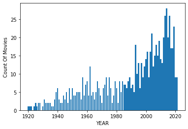

```python
y = pd.DataFrame(da['year'].value_counts())
plt.bar(y.index,y.year)
plt.xlabel('YEAR')
plt.ylabel('Count Of Movies')
```

*Lets see the most popular movie grouped by th decade:*

```python
H = np.array(pd.DataFrame(da.loc[:,('Decade','rating')].groupby('Decade').max())['rating'])
filt = da['rating'].isin(H[0:9])
da[filt].loc[:,('title','Decade','rating')].sort_values(by = 'Decade').head(10).set_index(np.arange(1,11,1))
```

|  | title | Decade | rating |
| --- | --- | --- | --- |
| 1 | The Kid | (1920, 1930] | 8.3 |
| 2 | Metropolis | (1920, 1930] | 8.3 |
| 3 | M - Eine Stadt sucht einen Mörder | (1930, 1940] | 8.3 |
| 4 | Modern Times | (1930, 1940] | 8.5 |
| 5 | City Lights | (1930, 1940] | 8.5 |
| 6 | Citizen Kane | (1940, 1950] | 8.3 |
| 7 | Double Indemnity | (1940, 1950] | 8.3 |
| 8 | Ladri di biciclette | (1940, 1950] | 8.3 |
| 9 | Casablanca | (1940, 1950] | 8.5 |
| 10 | It's a Wonderful Life | (1940, 1950] | 8.6 |

*Lets see the most succesfull movie grouped by decade:*

```python
H1 = np.array(pd.DataFrame(da.loc[:,('Decade','gross(in million dollars)')].groupby('Decade').max())['gross(in million dollars)'])
filt1 = da['gross(in million dollars)'].isin(H1[0:9])
da[filt1].loc[:,('title','Decade','gross(in million dollars)')].sort_values(by = 'Decade').head(10).set_index(np.arange(1,11,1))
```

|  | title | Decade | gross(in million dollars) |
| --- | --- | --- | --- |
| 1 | The Kid | (1920, 1930] | 5.45 |
| 2 | The Gold Rush | (1920, 1930] | 5.45 |
| 3 | Gone with the Wind | (1930, 1940] | 198.68 |
| 4 | The Best Years of Our Lives | (1940, 1950] | 23.65 |
| 5 | The Ten Commandments | (1950, 1960] | 93.74 |
| 6 | The Sound of Music | (1960, 1970] | 163.21 |
| 7 | Star Wars | (1970, 1980] | 322.74 |
| 8 | E.T. the Extra-Terrestrial | (1980, 1990] | 435.11 |
| 9 | Titanic | (1990, 2000] | 659.33 |
| 10 | Avatar | (2000, 2010] | 760.51 |

Its intresting to see that in almost every decade the most rated and grossed movies are diffrent

**Lets look the stars , i will analyze my two favourite actors Al pacino and Robert De Niro ::**

```python
filt_al = []
for i in da['stars'] :
    filt_al.append(' Al Pacino ' in i)
r = round(da[filt_al].rating.mean(),2)
ap =  da[filt_al].title.value_counts().sum()
g = round(da[filt_al]['gross(in million dollars)'].mean(),2)
print('     Al pacinpo     ')
print('--------------------------')
print(f'Total money movies done : {ap}')
print(f'Average Rating : {r}')
print(f'Total Money movies have made ${g}M')
```

```
     Al pacinpo
--------------------------
Total money movies done : 9
Average Rating : 8.24
Total Money movies have made $54.68M
```

```python
filt_bob = []
for i in da['stars'] :
    filt_bob.append(' Robert De Niro ' in i)
r = round(da[filt_bob].rating.mean(),2)
ap =  da[filt_bob].title.value_counts().sum()
g = round(da[filt_bob]['gross(in million dollars)'].mean(),2)
print('     Robert De Niro     ')
print('--------------------------')
print(f'Total money movies done : {ap}')
print(f'Average Rating : {r}')
print(f'Total Money movies have made ${g}M')
```

```
     Robert De Niro
--------------------------
Total money movies done : 15
Average Rating : 8.15
Total Money movies have made $54.7M
```

*Thanks for reading, if any suggestion or query please feel free to contact me*